# PeMS Regional Flow and CHP Starts: A Complete bdynets Tutorial

## 1 Data and sources

The case combines road flow and reported event starts on 16 June 2026:

- Caltrans PeMS D04 supplies native five-minute mainline detector counts;
- a project PeMS archive supplies hourly Los Angeles position values;
- project road records supply directed link geometry and endpoint station IDs;
- Caltrans CHP supplies reported incident starts and locations.

Read the complete prepared day used for the dataset summary and later checks.

```r
prepared_file <- "data/input.rds"
day_input <- readRDS(prepared_file)
```

Source roles

| Source | Native_data | Standard_result |
| --- | --- | --- |
| Caltrans PeMS D04 | Five-minute detector counts | Hourly station totals |
| Project PeMS archive | Hourly active-position values | Hourly station means |
| Project road records | Directed links and endpoint stations | roads and endpoint-mean flow |
| Caltrans CHP | Reported event starts and coordinates | events |

Complete prepared dataset

| Item | Value |
| --- | --- |
| Roads | 6638 |
| Hourly frames | 24 |
| Road-hour records | 159312 |
| Reported starts | 1019 |
| Regions | 2 |
| Flow unit | vehicles/hour |

The source clock carries no UTC offset. CHP points identify reported starts at their supplied locations.

## 2 Raw input and field meanings

### 2.1 Inspect the original-format teaching excerpt

The teaching excerpt retains two D04 detectors, two Los Angeles binary positions, three display links, and one CHP record at 08:00.

These records are an original-format excerpt from the same 2026-06-16 example. The report checks the converted link-hour values against the corresponding keys in `data/input.rds`. The excerpt explains the calculations; the two regional maps and daily curves use the complete prepared day.

```r
register_file <- "data/raw/links.rds"
archive_files <- setNames(
  file.path("data/raw", c(
    "detector.txt.gz", "stations.txt", "station-map.csv",
    "flow_2026_06.binz", "manifest.json", "geometry.html",
    "incidents.txt.gz", "details.txt.gz"
  )),
  c("detector", "metadata", "station_map", "hourly", "manifest",
    "geometry", "incidents", "details")
)

native <- read_pems_archives(
  register_file = register_file,
  files = archive_files
)

d04_raw <- read.csv(
  archive_files[["detector"]], header = FALSE,
  colClasses = "character"
)
la_columns <- read.csv("data/raw/binary-columns.csv", colClasses = "character")
chp_raw <- read.csv(
  archive_files[["incidents"]], header = FALSE,
  colClasses = "character", na.strings = NULL
)
```

Original-format D04 records (first six rows)

| V1 | V2 | V3 | V6 | V10 |
| --- | --- | --- | --- | --- |
| 06/16/2026 08:00:00 | 400001 | 4 | ML | 407 |
| 06/16/2026 08:00:00 | 404753 | 4 | ML | 398 |
| 06/16/2026 08:05:00 | 400001 | 4 | ML | 364 |
| 06/16/2026 08:05:00 | 404753 | 4 | ML | 415 |
| 06/16/2026 08:10:00 | 400001 | 4 | ML | 409 |
| 06/16/2026 08:10:00 | 404753 | 4 | ML | 341 |

Decoded binary positions, station IDs, and selected-hour values

| fixture_binary_column | source_binary_column | position | station_id | value_at_selected_hour |
| --- | --- | --- | --- | --- |
| 0 | 1072 | 1317 | 716028 | 1402 |
| 1 | 2939 | 3296 | 776906 | 1791 |

Original CHP summary fields

| V1 | V4 | V5 | V6 | V7 | V10 | V11 | V12 |
| --- | --- | --- | --- | --- | --- | --- | --- |
| 23633415 | 06/16/2026 08:00:00 | 1184-Provide Traffic Control | Us101 S / Sir Francis Drake Ofr | Marin | 37.947769 | -122.513263 | 4 |

Key source fields

| Source_field | Meaning | Standard_destination |
| --- | --- | --- |
| D04 V1 | Five-minute source timestamp | Hourly frame |
| D04 V2 | Detector station ID | Endpoint station join |
| D04 V10 | Five-minute total flow | Station-hour total |
| LA binary value | Unsigned hourly position value; 65535 means missing | Station mean and link flow |
| CHP V4 | Reported start | events time |
| CHP V10/V11 | Latitude (V10) and longitude (V11) | events lat (V10); events lon (V11) |
| CHP V12 | District | events region |

The raw sources use different storage formats and clocks. The example reader preserves their IDs and values in a native object before constructing canonical package tables.

A temporary `source.rds` readback confirms that the imported source records are unchanged.

### 2.2 Deliberately invalid input and correction

This check maps the original unnamed detector columns for `pems_counts()`. A D04 station and five-minute timestamp must identify exactly one observed count. The following in-memory copy duplicates the first mainline record; no source file is changed.

```r
d04_fields <- c(time = "V1", station = "V2", count = "V10")
```

[output not shown]

Removing the duplicate restores the complete station–timestamp grid. Missing source counts are not silently replaced with zero.

```
##   stations five_minute_slots duplicate_keys missing_counts
## 1        2                12              0              0
```

## 3 Convert with the road plotting interface

`pems_input()` is an **example adapter**, not a public package API. It implements the PeMS-specific hourly calculations, endpoint joins, event parsing, and source validation. Its output tables are extracted below as the canonical inputs required by the road table interface.

### 3.1 Prepare canonical tables

```r
adapter_output <- pems_input(native)

roads <- adapter_output[["roads"]]
flow <- adapter_output[["flow"]]
events <- adapter_output[["events"]]
times <- adapter_output[["times"]]
interval_seconds <- adapter_output[["interval_seconds"]]
```

Collect the tables and time metadata in the same working format as the other Flow examples.

### 3.2 Assemble road-map arguments

```r
road_input <- list(crs = "EPSG:4326",
  roads = roads,
  flow = flow,
  events = events,
  times = times,
  interval_seconds = interval_seconds,
  unit = adapter_output[["unit"]],
  provenance = adapter_output[["provenance"]]
)
```

The result is a data-only named list. It retains roads, flow, reported events, frame starts, interval widths, units and provenance; it does not contain a selected display label, title, palette or basemap.

### 3.3 What does `road_input` contain?

Prepared roads table

| road_id | from_station | to_station | region |
| --- | --- | --- | --- |
| 0 | 716028 | 776906 | Los Angeles Area |
| 765 | 764115 | 764120 | Los Angeles Area |
| D04:101:N:400001:404753 | 400001 | 404753 | San Francisco Bay Area |

Prepared road-hour flow table

| road_id | time | flow |
| --- | --- | --- |
| 0 | 1781596800 | 1596.5 |
| 765 | 1781596800 | NA |
| D04:101:N:400001:404753 | 1781596800 | 4695.0 |

Prepared reported-start event table

| id | time | lon | lat | category | description | time_label | region |
| --- | --- | --- | --- | --- | --- | --- | --- |
| 23633415 | 1781596800 | -122.5133 | 37.94777 | Road control | 1184-Provide Traffic Control \| Us101 S / Sir Francis Drake Ofr \| Marin | 2026-06-16 08:00:00 | San Francisco Bay Area |

For the teaching excerpt, the two D04 station-hour totals are 4,601 and 4,789, giving endpoint mean 4,695. The Los Angeles endpoints give 1,402 and 1,791, producing 1,596.5. Both endpoints of road 765 are unavailable, so that road-hour remains `NA`; it is not replaced by zero.

The transformation has four levels:

- **Sensor observations:** D04 five-minute values remain native station counts before aggregation.
- **Station-hour values:** twelve D04 counts are summed; Los Angeles active positions are averaged within station.
- **Display links:** available endpoint-station values are averaged, which can produce fractional values and does not create a directly observed link sensor.
- **Events and metadata:** CHP records retain their reported-start meaning, source IDs, source clock, region, and provenance.

Road maps take `roads` and `flow` tables with their time and units. Events and additional measurements are optional road-map inputs. OD maps use separate station and trip tables.

## 4 Pass the road input to `traffic_flow_map()`

### 4.1 Draw the bundled frame

In a fresh R session with this example’s directory as the working directory, load the bundled package and read the supplied 08:00 single-frame RDS and pass it directly to the plotter. The same file contains both regions; use `"San Francisco Bay Area"` for the Bay Area.

```r
source("../../bdynets/inst/preparation-session.R")
preparation_session(getwd())
library(bdynets)
frame <- readRDS("data/map-frame-0800.rds")
traffic_flow_map(frame, region = "Los Angeles Area", basemap = NULL)
```

### 4.2 Prepare a frame for the report

The report prepares a frame at the requested clock time from the full-day data. It uses the full day for the daily curves. The prepared hourly frame includes CHP starts in that interval.

```r
road_args <- day_input[intersect(names(day_input), names(formals(traffic_data)))]
# UTC decodes the numeric wall-clock encoding without assigning a source timezone.
road_args$time_labels <- format(as.POSIXct(road_args$times, origin = "1970-01-01", tz = "UTC"),
                                "%Y-%m-%d %H:%M", tz = "UTC")
frame_index <- which(substr(road_args$time_labels, 12L, 16L) == params$time_label)
if (length(frame_index) != 1L) stop("Choose one existing map frame in HH:MM.")

frame_args <- road_args
frame_args$times <- road_args$times[frame_index]
frame_args$time_labels <- road_args$time_labels[frame_index]
frame_args$interval_seconds <- road_args$interval_seconds[frame_index]
frame_args$flow <- road_args$flow[road_args$flow$time == frame_args$times, , drop = FALSE]
frame_args$events <- road_args$events[
  road_args$events$time >= frame_args$times &
    road_args$events$time < frame_args$times + frame_args$interval_seconds, , drop = FALSE
]
day_view <- do.call(traffic_data, road_args)
frame_view <- do.call(traffic_data, frame_args)
map_input <- frame_view
map_input$time_labels <- NULL
map_input$time_label_format <- "%Y-%m-%d %H:%M"
```

### 4.3 Los Angeles Area

```r
la_map <- traffic_flow_map(
  frame_view,
  region = "Los Angeles Area",
  basemap = if (params[["basemap"]])
    traffic_basemap(day_view, region = "Los Angeles Area", cache_dir = "data/basemap-cache",
      offline = TRUE, road_classes = character()) else NULL,
  flow_style = list(
    breaks = c(3.04, 15.3, 64.9, 265, 1070, 4340),
    labels = c("0 to < 3.04", "3.04 to < 15.3", "15.3 to < 64.9", "64.9 to < 265",
               "265 to < 1,070", "1,070 to < 4,340", ">= 4,340"),
    palette = c("#16a43a", "#7ad151", "#f7ea2a", "#ffc928",
                "#f5a623", "#f36b2b", "#f01818"),
    right = FALSE
  ),
  title = "PeMS flow and CHP reported starts",
  caption = paste0("Frame ", params$time_label,
    "; Los Angeles hourly endpoint-mean flow and reported event starts.")
)
```

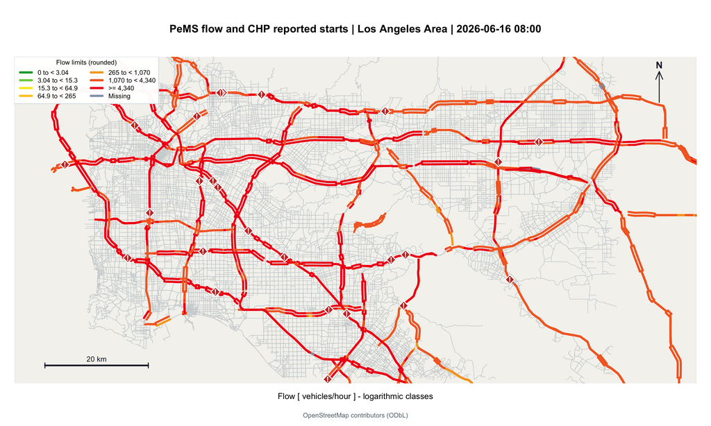

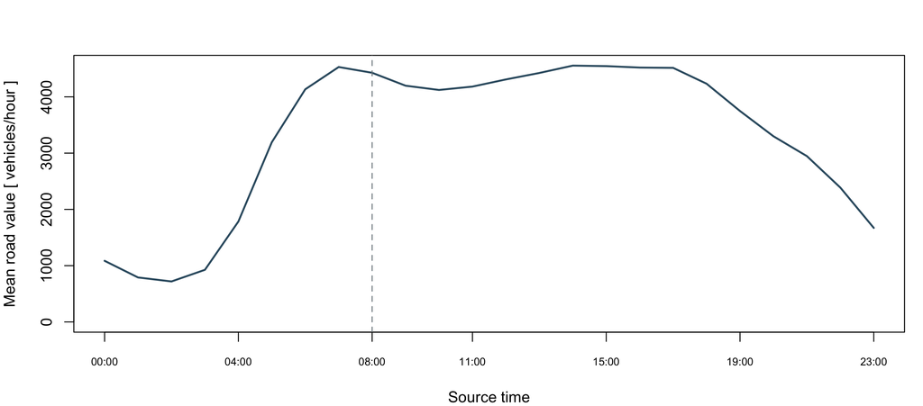

```r
la_trend <- traffic_trend(day_view, region = "Los Angeles Area")
plot(la_trend, metric = "mean", index = frame_index)
```

### 4.4 San Francisco Bay Area

```r
bay_map <- traffic_flow_map(
  frame_view,
  region = "San Francisco Bay Area",
  basemap = if (params[["basemap"]])
    traffic_basemap(day_view, region = "San Francisco Bay Area", cache_dir = "data/basemap-cache",
      offline = TRUE, road_classes = character()) else NULL,
  flow_style = list(
    breaks = c(3.04, 15.3, 64.9, 265, 1070, 4340),
    labels = c("0 to < 3.04", "3.04 to < 15.3", "15.3 to < 64.9", "64.9 to < 265",
               "265 to < 1,070", "1,070 to < 4,340", ">= 4,340"),
    palette = c("#16a43a", "#7ad151", "#f7ea2a", "#ffc928",
                "#f5a623", "#f36b2b", "#f01818"),
    right = FALSE
  ),
  title = "PeMS flow and CHP reported starts",
  caption = paste0("Frame ", params$time_label,
    "; Bay Area hourly endpoint-mean flow and reported event starts.")
)
```

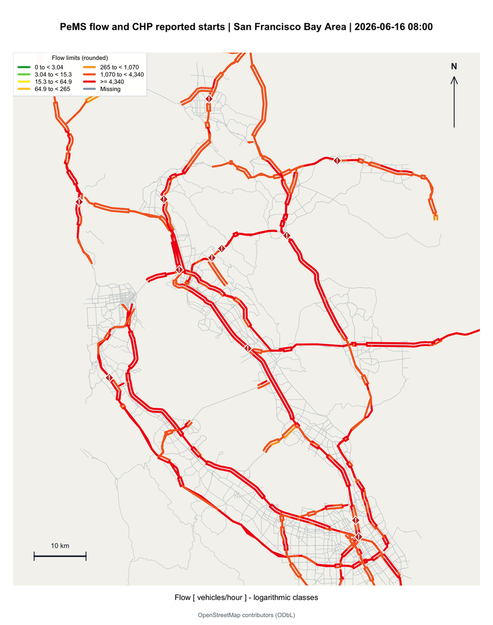

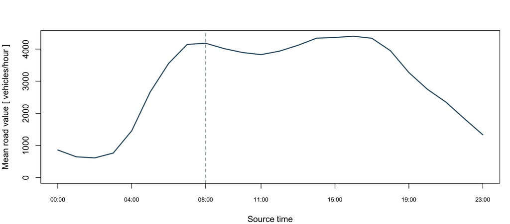

```r
bay_trend <- traffic_trend(day_view, region = "San Francisco Bay Area")
plot(bay_trend, metric = "mean", index = frame_index)
```

Map color represents hourly endpoint-mean flow. Diamonds represent reported starts in the selected hour; they do not imply that an event caused a change in flow. Each trend is a regional mean across available road values, not a regional vehicle total.

## 5 Validate the conversion

Core validation results

| Check | Passed |
| --- | --- |
| Teaching flow records agree with the complete prepared day | TRUE |
| Teaching event agrees with the complete prepared day | TRUE |
| Complete flow row count equals roads multiplied by frames | TRUE |
| No duplicated road_id-time keys are present | TRUE |
| Fractional display-link values equal the documented total | TRUE |
| Missing display-link values equal the documented total | TRUE |
| Event IDs and reported starts are unique and retained | TRUE |
| Observed flow values are finite and nonnegative | TRUE |
| Source files remain unchanged during report generation | TRUE |

Complete-data coverage

| Roads | Frames | Interval (minutes) | Total records | Missing records | Observed zeros | Reported starts | Unit |
| --- | --- | --- | --- | --- | --- | --- | --- |
| 6638 | 24 | 60 | 159312 | 1344 | 60 | 1019 | vehicles/hour |

Every validation row must be `TRUE`. Fractional display-link values arise from endpoint averaging; missing links remain `NA`. Reported event starts are descriptive markers, not inferred incident durations or causal effects.

## 6 Reproduce the report

From the bundle root, render the report without background streets.

```bash
Rscript examples/largest/run.R --offline
```

`basemap=FALSE` requires no network. With `basemap=TRUE`, verified caches may be reused; a new background request requires network access. The source records, road geometry, values, events, validation, and exports do not depend on a basemap.

Common problems include duplicated or missing station–timestamp keys, source station IDs absent from the declared register, incomplete groups of twelve D04 slots, unmatched endpoint stations, and reuse of an existing export directory. Do not convert a missing sensor count into zero without a documented completeness rule.

Add `--export` to also write `output/prepared-data/` and `output/figures/` in this example’s directory. The `output/figures/map-input.rds` file can be drawn directly.

## Appendix

### Adapt renamed detector columns

The source-role mapping, rather than fixed column positions in downstream code, lets the validator read equivalent detector data with different headers.

```r
renamed_d04 <- d04_mainline[c("V1", "V2", "V10")]
names(renamed_d04) <- c("timestamp", "sensor_id", "five_minute_count")
renamed_fields <- c(
  time = "timestamp",
  station = "sensor_id",
  count = "five_minute_count"
)
mapped_counts <- pems_counts(
  renamed_d04,
  station_ids = native$d04$station_id,
  labels = d04_labels,
  fields = renamed_fields
)
stopifnot(identical(unname(mapped_counts), unname(correct_counts)))
head(renamed_d04)
```

```
##             timestamp sensor_id five_minute_count
## 1 06/16/2026 08:00:00    400001               407
## 2 06/16/2026 08:00:00    404753               398
## 3 06/16/2026 08:05:00    400001               364
## 4 06/16/2026 08:05:00    404753               415
## 5 06/16/2026 08:10:00    400001               409
## 6 06/16/2026 08:10:00    404753               341
```

Only the mapping changes. The hourly aggregation, endpoint averaging, road_input constructor, plotting, and export interfaces remain unchanged.

### Export, read back, and reuse

The teaching `road_input` object is published to a new temporary directory. The export includes RDS and CSV tables, ordered geometry vertices, a data dictionary, validation records, source identities, metadata, and checksums.

```r
prepared_export_dir <- tempfile("largest-prepared-export-")
dictionary <- read.csv("data/data-dictionary.csv", stringsAsFactors = FALSE)
dictionary_key <- paste(dictionary$table, dictionary$field, sep = "/")
standard_key <- unlist(lapply(
  c("roads", "flow", "events"),
  function(table) paste(table, names(road_input[[table]]), sep = "/")
))
dictionary <- dictionary[dictionary_key %in% standard_key, ]

declared_sources <- c(register_file, unname(archive_files))
prepared_path <- write_traffic_input(
  road_input,
  prepared_export_dir,
  source_files = declared_sources,
  native = native,
  dictionary = dictionary
)
restored <- readRDS(prepared_path)
```

Prepared-data export files

| file |
| --- |
| checksums.csv |
| data-dictionary.csv |
| events.csv |
| flow.csv |
| input.rds |
| metadata.json |
| road-vertices.csv |
| roads.csv |
| source-files.csv |
| source.rds |
| validation.csv |

Prepared-data readback checks

| Check | Passed |
| --- | --- |
| RDS core fields read back unchanged | TRUE |
| CSV IDs, times, values, and missingness read back correctly | TRUE |
| Dictionary and validation files are present | TRUE |
| Prepared-export checksums agree | TRUE |
| Source files remain unchanged | TRUE |

#### Export figures and selected records

The figure export uses the same full prepared day, selected hour, and Los Angeles scope as the displayed map.

The figure export also saves the chosen frame as `map-input.rds` for direct drawing and includes `selected-frame.rds` as a verification snapshot.

```r
export_selected_map <- function(directory) {
  if (file.exists(directory)) stop("The requested export directory already exists.")
  staging <- tempfile("pems-figure-export-", tmpdir = dirname(directory))
  export_view <- day_view
  export_view$title <- la_map$data$title
  export_view$scale <- la_map$data$scale
  export_view$basemap <- la_map$data$basemap
  previous_options <- options(bdynets.basemap.auto = FALSE)
  on.exit({
    options(previous_options)
    unlink(staging, recursive = TRUE)
  })
  traffic_export(
    export_view,
    staging,
    index = frame_index,
    region = "Los Angeles Area",
    input_files = c(prepared = prepared_file)
  )

  # Use the map's selected event extent and keep the exported all-day trends.
  grDevices::png(file.path(staging, "map.png"), width = 2400, height = 1800,
                 res = 240, type = getOption("bitmapType"))
  tryCatch(plot(la_map$data, region = "Los Angeles Area"), finally = grDevices::dev.off())
  grDevices::pdf(file.path(staging, "map.pdf"), width = 10, height = 7.5, useDingbats = FALSE)
  tryCatch(plot(la_map$data, region = "Los Angeles Area"), finally = grDevices::dev.off())

  manifest_file <- file.path(staging, "checksums.csv")
  manifest <- read.csv(manifest_file, stringsAsFactors = FALSE)
  maps <- match(c("map.png", "map.pdf"), manifest$file)
  map_files <- file.path(staging, manifest$file[maps])
  manifest$bytes[maps] <- file.info(map_files)$size
  manifest$md5[maps] <- unname(tools::md5sum(map_files))
  map_path <- file.path(staging, "map-input.rds")
  saveRDS(map_input, map_path, compress = "xz")
  manifest <- rbind(manifest, data.frame(file = basename(map_path),
    bytes = file.info(map_path)$size, md5 = unname(tools::md5sum(map_path))))
  manifest <- manifest[order(manifest$file), , drop = FALSE]
  write.csv(manifest, manifest_file, row.names = FALSE)
  if (!file.rename(staging, directory)) stop("Cannot publish the figure export.")
}

figure_export_dir <- tempfile("largest-figure-export-")
export_selected_map(figure_export_dir)
```

Figure-export files

| file |
| --- |
| checksums.csv |
| event-trend.pdf |
| event-trend.png |
| flow-trend.pdf |
| flow-trend.png |
| inputs.csv |
| map-input.rds |
| map.pdf |
| map.png |
| provenance.json |
| selected-frame.rds |
| session-info.txt |
| summary.csv |
| trend.csv |

Figure-export checks

| Check | Passed |
| --- | --- |
| PNG and PDF map files are present | TRUE |
| Direct map input, frame snapshot, and provenance are present | TRUE |
| Figure-export checksums agree | TRUE |

```r
if (params$export) {
  if (file.exists(params$export_dir)) stop("The requested export directory already exists; choose a new directory.")
  dir.create(params$export_dir, recursive = TRUE)
  write_traffic_input(
    road_input,
    file.path(params$export_dir, "prepared-data"),
    source_files = declared_sources,
    native = native,
    dictionary = dictionary
  )
  export_selected_map(file.path(params$export_dir, "figures"))
}
```

### Source records and session

Original archives and source identities

| file | provider | role |
| --- | --- | --- |
| d04_text_station_5min_2026_06_16.txt.gz | Caltrans PeMS | D04 five-minute counts |
| d04_text_meta_2026_04_08.txt.gz | Caltrans PeMS | D04 station coordinates and identifiers |
| flow_2026_06.binz | Project PeMS archive | LA hourly values |
| manifest.json | Project PeMS archive | binary position order |
| la_area_freeway_volume_2020_01_to_2026_06.html | Project PeMS archive | station mapping and LA geometry |
| snapshot_d04_2026-04-08.csv | Project station mapping | D04 display selection |
| all_text_chp_incidents_month_2026_06.txt.gz | Caltrans CHP | incident summaries |
| all_text_chp_incident_det_month_2026_06.txt.gz | Caltrans CHP | incident messages |
| events.csv | Project annotation | LA English incident summaries |

Bundled teaching sources and selections

| file | selection |
| --- | --- |
| detector.txt.gz | All original fields; stations 400001 and 404753; 08:00-08:55; 24 ML rows. |
| stations.txt | Original fields for the two selected endpoint stations. |
| station-map.csv | The same two endpoint station IDs from the dated map. |
| flow_2026_06.binz | All 720 source hours; original zero-based binary columns 1072 and 2939; unsigned 16-bit little endian. |
| manifest.json | June entry; global source positions 1317 and 3296; two projected columns and unchanged 720 source hours. |
| binary-columns.csv | Explicit zero-based fixture/source binary columns and original positions; station IDs agree with the original configuration. |
| geometry.html | Links 0 and 765 plus the unchanged source position-to-station register. |
| incidents.txt.gz | All original fields for incident 23633415. |
| details.txt.gz | All eleven original detail lines for incident 23633415. |
| links.rds | Existing LA links 0 and 765 and D04:101:N:400001:404753; original scope/category/direction rules; requested hour 08:00. |

Conversion and entry-point source identities

| file | sha256 |
| --- | --- |
| prepare.R | 60757bd35edcac4e80ffdf21fdc474405d55d751d81fdab7bb430d34f1e726bc |
| run.R | 27086237cff0589bad26e69d42c705fa4e6e2fbd5c2d1c69c6cc36e13eb73324 |

```
## Package version: 0.2.1
```

```
## Bundled source revision (SHA-256): f522883318e2a3a298456f1273f2887f8fd98e28399aafb059eeedff41539253
```

```
## Report computation elapsed: 69.9 seconds
```